# Wavelets_in_R

Brendan Law

5 March 2019

## Wavelets in R

Just trying to emulate basic Haar Discrete Wavelet Transform in R (the original DWT). Using the ‘USAccDeaths’ dataset (a time series), here is some code that wavelet transforms this time series.

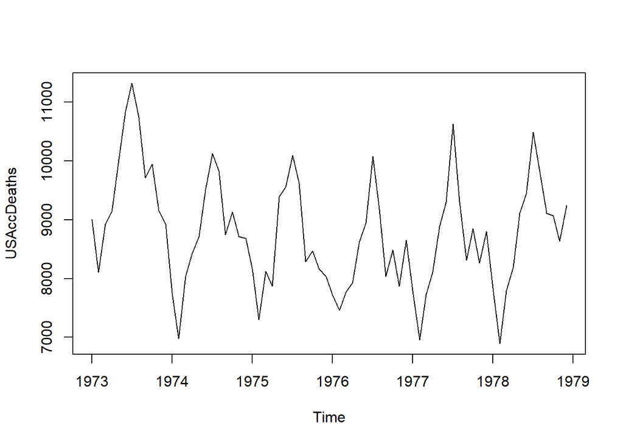

Now here is some code in the ‘wavelets’ library to do a Haar DWT on the time series. We can see that there are two decomopositions, ‘W’ and ‘V’:

```r
library(wavelets)
wc <- wavelets::dwt(c(USAccDeaths), filter = "haar")
attr(wc,'W')
```

```
## $W1
##             [,1]
##  [1,] -637.10321
##  [2,]  147.78532
##  [3,]  572.04939
##  [4,] -405.17219
##  [5,]  159.09903
##  [6,] -165.46299
##  [7,] -543.76511
##  [8,]  271.52900
##  [9,]  564.27121
## [10,] -210.01071
## [11,]  272.94322
## [12,]  -21.21320
## [13,] -605.28340
```

[output cut: 72 more lines]

```r
attr(wc,'V')
```

```
## $V1
##           [,1]
##  [1,] 12100.72
##  [2,] 12773.88
##  [3,] 14738.23
##  [4,] 15599.48
##  [5,] 13895.36
##  [6,] 12790.15
##  [7,] 10416.39
##  [8,] 11638.98
##  [9,] 12887.73
## [10,] 14101.83
## [11,] 12637.41
## [12,] 12296.59
## [13,] 10937.53
```

[output cut: 72 more lines]

So what do these mean? Presumably, the first level (W1, V1) are the lowest level (finest) scales. But why are there two? Are there two types of transforms, or perhaps they use each other. Another thing we know is the top level is half the length (36) of the full dataset (72), so its clear that some aggregation is going on. In this case, we suspect subtraction, which it is, up to some scaling constant. The scaling constant happens to be $\frac{1}{\sqrt(2)}$, which I believe is something to do with making the basis vectors orthnormal (length 1).

Turns out that W is the difference between adjacent terms, recursed to the most granular level.

```r
# Look at W for example

# Not quite the same
USAccDeaths[2]-USAccDeaths[1]
```

```
## [1] -901
```

```r
attr(wc,'W')$W1[1]
```

```
## [1] -637.1032
```

```r
# Scaling factor of 1/sqrt(2)
(USAccDeaths[2]-USAccDeaths[1])/attr(wc,'W')$W1[1]
```

```
## [1] 1.414214
```

```r
round(attr(wc,'W')$W1[1],10) == round((USAccDeaths[2]-USAccDeaths[1]) * 1/sqrt(2),10)
```

```
## [1] TRUE
```

```r
# Same scaling everywhere
for(i in 1:length(attr(wc,'W')$W1)){
  print((USAccDeaths[2*i]-USAccDeaths[2*i-1])/attr(wc,'W')$W1[[i]])
}
```

```
## [1] 1.414214
## [1] 1.414214
## [1] 1.414214
## [1] 1.414214
## [1] 1.414214
## [1] 1.414214
## [1] 1.414214
## [1] 1.414214
## [1] 1.414214
## [1] 1.414214
## [1] 1.414214
## [1] 1.414214
## [1] 1.414214
## [1] 1.414214
## [1] 1.414214
```

[output cut: 21 more lines]

What is series V? Turns out it’s the addition of the first two elements, etc etc.

```r
# Look at V for example

# Not quite the same
USAccDeaths[2]+USAccDeaths[1]
```

```
## [1] 17113
```

```r
attr(wc,'V')$V1[1]
```

```
## [1] 12100.72
```

```r
# Scaling factor of 1/sqrt(2)
(USAccDeaths[2]+USAccDeaths[1])/attr(wc,'V')$V1[1]
```

```
## [1] 1.414214
```

```r
round(attr(wc,'V')$V1[1],10) == round((USAccDeaths[2]+USAccDeaths[1]) * 1/sqrt(2),10)
```

```
## [1] TRUE
```

```r
# Same scaling everywhere
for(i in 1:length(attr(wc,'W')$W1)){
  print((USAccDeaths[2*i]+USAccDeaths[2*i-1])/attr(wc,'V')$V1[[i]])
}
```

```
## [1] 1.414214
## [1] 1.414214
## [1] 1.414214
## [1] 1.414214
## [1] 1.414214
## [1] 1.414214
## [1] 1.414214
## [1] 1.414214
## [1] 1.414214
## [1] 1.414214
## [1] 1.414214
## [1] 1.414214
## [1] 1.414214
## [1] 1.414214
## [1] 1.414214
```

[output cut: 21 more lines]

Now for some plots…

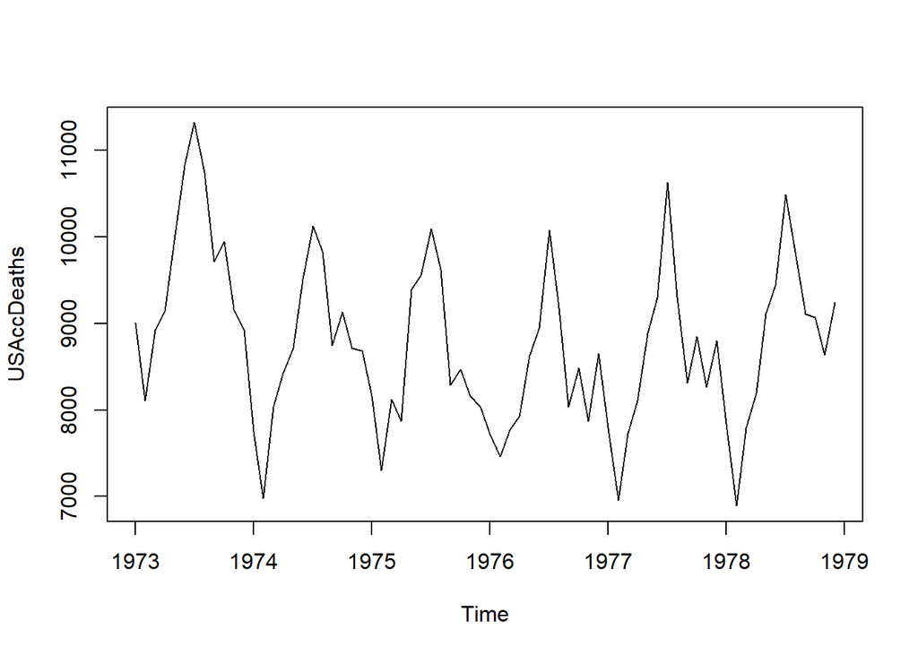

```r
plot(USAccDeaths)
```

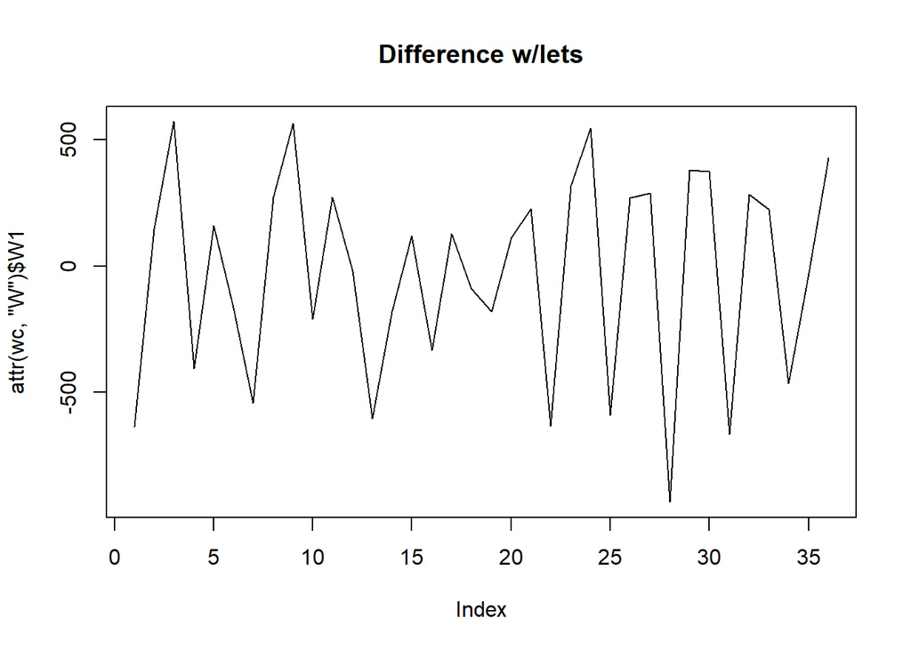

```r
plot(attr(wc,'W')$W1, main = 'Difference w/lets', type = "l")
```

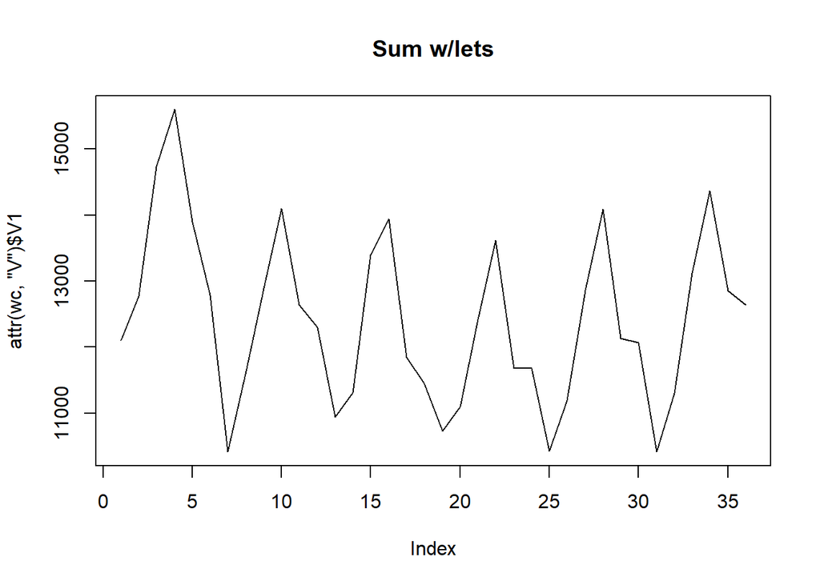

```r
plot(attr(wc,'V')$V1, main = 'Sum w/lets', type = "l")
```

To go one level up, we take the added wavelet coefficients (stored in V), and aggregate them by differencing (result will be W2), or summing (result will be V2).

```r
# Differencing
(attr(wc,'V')$V1[2] - attr(wc,'V')$V1[1])/attr(wc,'W')$W2[1]
```

```
## [1] 1.414214
```

```r
# Summing
(attr(wc,'V')$V1[2] + attr(wc,'V')$V1[1])/attr(wc,'V')$V2[1]
```

```
## [1] 1.414214
```

Etc. And this is how we work our way up the wavelet ‘tree’. Turns out (according to HJ’s presentation), we just take the differences at each level, which corresponds to only using the ‘W’ part of the wavelet transform (V just for working). Although it should be analogous to just taking the W part - both should have the same informational content? (Both are 1:1, as long as one or the other are used?)